# Tourist flats in Barcelona

author: Jag

September 2018

### Loading libraries

```r
library(readr)
library(dplyr)
library(ggplot2)
library(forcats)
library(stringr)
library(ggrepel)
```

### Importing files

**Data source**: open data portal run by the Town Hall, datasets: [“Tourist housing in the city of Barcelona”](http://opendata-ajuntament.barcelona.cat/data/en/dataset/habitatges-us-turistic) and [“Population by neighbourhoof, nationality and genre of the city of Barcelona”](http://opendata-ajuntament.barcelona.cat/data/en/dataset/est-padro-nacionalitat-sexe)

```r
viviendas <- read.csv("http://opendata-ajuntament.barcelona.cat/data/dataset/c748799e-1079-44b1-9e60-88d936a3fe70/resource/a5a6cae9-a5d7-47e9-ab39-15b600210a0b/download", fileEncoding = "UTF-8")
population <-  read.csv("http://opendata-ajuntament.barcelona.cat/data/dataset/3a0934e4-cdba-4056-950a-331429cb8908/resource/da151a88-9dbe-4715-9ebd-9982506deb85/download/2018_padro_nacionalitat_per_sexe.csv", fileEncoding = "UTF-8")
pop <- select(population, code=Codi_Districte,district=Nom_Districte,gender=Sexe,nacionality=Nacionalitat,Ppl=Nombre)
```

### Analysis steps and issues:

1. **Import data**. Troubleshoot encoding (catalan symbols)
2. **Wrangling data and joining tables.** Dataset were fairly tidy, but not perfect. For tourist housing, each row was one flat, so I calculated nr of flats per district, cleaned district names and added column with district codes to be able to join it with other dataset. Population data came with each row equal to barrio (sub-district) and I used to compute estimated number of local housing in following steps: calculate population per district, calculate estimated number of flats per district using standard HH size (source included in code). Finally, using both dataset which were join to one table, I calculated number of tourist flat per 100 local flats (ratio).
3. **Visualisation.** Of course I went thorugh few iteration and type of graphs, but I decided to share two: bar graph showing tourist housing per district, which was first one I made and which made me question ratio of tourist housing to population/local housing. It’s very simple but I took it as opportunity to play with layout, hope it’s neat. Final visualisation is the scatterplot comparing tourist housing vs local housing, including ratio of tourist flats per 100 local flats as size factor. No fireworks, but should be also neat.

**Outcomes:** Depending in which district you would be in Barcelona, you can find from 0.03 to 4.19 tourist flats for every 100 local flats. That’s quite a few, isn’t it? Take a look on graphs to see where to stay to be out of the beaten track!

### Wrangling data

Calculating nr of tourist flats per district plus a bit of cleaning

```r
barrio <- viviendas %>%
          group_by(N_EXPEDIENT) %>%
          summarise(flats=n()) %>%
          arrange(desc(flats)) %>%
          rename(district=N_EXPEDIENT)
barrio$district <- as.character(barrio$district)
barrio$district <- str_to_title(barrio$district)
barrio$district <- str_replace(barrio$district, "L'e","E")
```

Calculating poplation per district

```r
pop_dist <- pop %>%
  group_by(district, code) %>%
  summarise(pop=sum(Ppl))
```

Now adding district codes to first table in order to have ID

```r
barrio2 <- mutate(barrio,
  code=as.numeric(case_when(
    district=="Ciutat Vella"~"1",
    district=="Eixample"~"2",
    district=="Sants-Montjuïc"~"3",
    district=="Les Corts"~"4",
    district=="Sarria-Sant Gervasi"~"5",
    district=="Gracia"~"6",
    district=="Horta-Guinardó"~"7",
    district=="Nou Barris"~"8",
    district=="Sant Andreu"~"9",
    district=="Sant Marti"~"10")))
```

and joining two tables

```r
table <- left_join(pop_dist,barrio2,by="code")
table <- select(table,district=district.x, code, pop,flats)
```

Some additional stats

```r
#average HH size in cataluna=2.49 Source: http://www.ine.es/en/prensa/ech_2017_en.pdf
table <- table %>%
  mutate(loc_flats=round((pop/2.49),digits=0)) %>%
  mutate(ratioPer100=round((flats*100)/loc_flats,digits=2))
table <- arrange(table, desc(pop))
```

### Creating graphs

Nr of flats per district

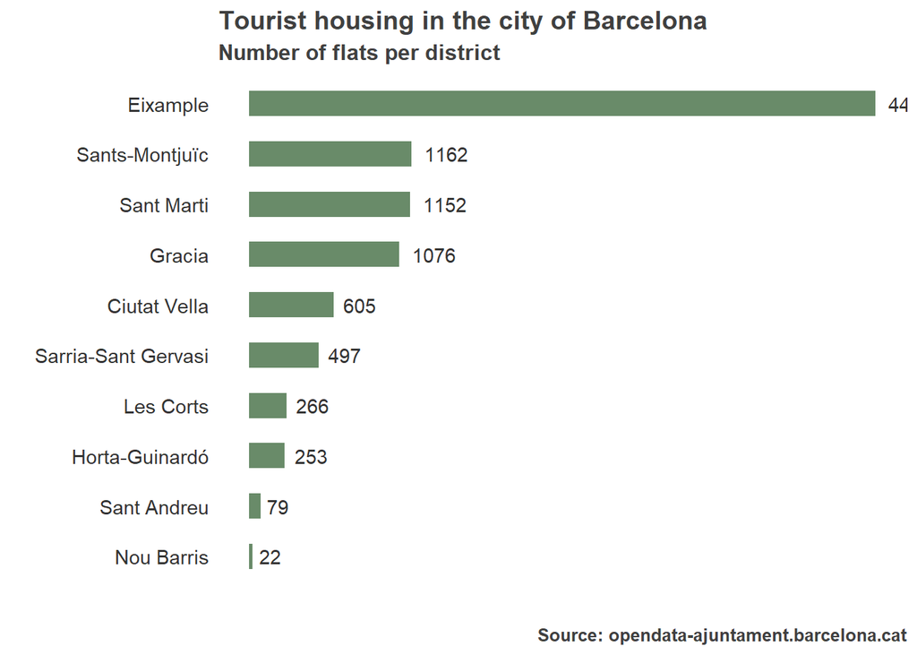

Nr of tourist housing VS local flats, per district

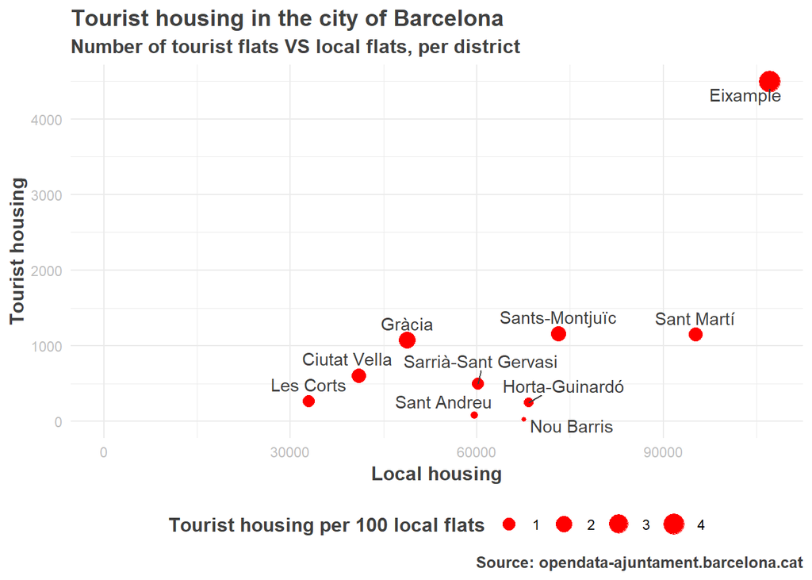